# The Gulf Wealth Narrative: Facts and Misreadings

What the “rich Middle East” story gets right, and the three things it gets wrong

Author

Gen

Published

June 2, 2026

# Introduction

Mention the Middle East and the image of fabulous wealth has become a cross-language stereotype. The classic Chinese tagline runs, “a cloth on the head, and the richest on Earth.” Netflix’s flashy reality show *Dubai Bling*, now into its third season, pushes the image to its limit.

Drawn by expectations of Middle Eastern money, many Chinese firms made the region the first stop in the recent wave of going abroad. But the tide receded just as quickly. Geopolitical conflict flares again and again; and marquee Saudi megaprojects such as The Line keep making headlines for delays and downgrades. Some have begun to ask whether the “Middle East tycoon” is just another bubble inflated by narrative.

This study’s answer is that Gulf wealth is no bubble, but the “Middle East tycoon” narrative misreads at least three things: it equates the entire Middle East with the GCC, it equates national wealth with wealth shared by everyone, and it equates a stock advantage with long-term, risk-free security. GCC wealth is real, vast, and highly institutionalized, yet it rests on three pillars: hydrocarbon rents, the exclusivity of citizenship, and a favorable geopolitical security environment. The report develops this judgment below.

# 1 Defining the “Middle East”: the geopolitical “Middle East” and the financial “GCC”

The Middle East conjures two utterly different pictures. On one side stand the luxury towers, supercars, and yachts of Dubai and Qatar; on the other, the war zones of Iran, Syria, and their neighbors. Both wear the label “Middle East,” yet the geographies they point to barely overlap. In fact, even across the definitions used by major international institutions, the list of countries the term denotes can swell from 6 to more than 30.

So the first step in any discussion of Gulf wealth is to pin down what “the Middle East” actually means.

## 1.1 The geopolitical “Middle East”: an externally coined name

“Middle East” is not a native Arabic term; from the day it was coined it was a strategic concept defined from the outside. Traditionally, Arabs divided their world into the *Mashriq* (المشرق, the “Arab East”) and the *Maghreb* (المغرب, the “Arab West”).

In 1902, the US naval officer Alfred Thayer Mahan, author of *The Influence of Sea Power upon History*, popularized “Middle East” in international strategic debate through an article in Britain’s *National Review* (Mahan 1902). Mahan’s “Middle East” referred specifically to the Persian Gulf waterway and its surroundings, on the grounds that this belt was the strategic linchpin for the British Empire’s defense of its colonial sea lanes.

Over the following century, the boundaries of the “Middle East” expanded and contracted with the prevailing geopolitical winds. In WWII, Britain’s “Middle East Command” pulled Cairo and North Africa under its remit; during the Cold War, the US-led collective-security architecture (such as the 1955 Baghdad Pact / CENTO) folded in Pakistan; and the George W. Bush administration’s 2004 “Greater Middle East” even drew in Afghanistan and parts of Central Asia (Adelson 1995; Davison 1960).

Today at least four parallel notions of the “Middle East” coexist:

- **Geographically**, it spans West Asia, the Arabian Peninsula, and the Levant, sometimes extending to North Africa and Iran.
- **Culturally**, it is treated as the successor space of Islamic civilization, the Arab world, or the Ottoman Empire, and so may take in North Africa, Central Asia, and even parts of South Asia.
- **Diplomatically**, the concept fractures further: even the regions drawn by the major international bodies differ sharply, and the UN sets up no “Middle East” statistical region at all, replacing it with the purely geographic “Western Asia” plus “Northern Africa.”
- **Economically**, the wealth gap inside these definitions is enormous. Qatar’s 2024 GDP per capita was about $77,000; Yemen’s was under $700, a gap of more than a hundredfold.

Table 1: How major international organizations define the Middle East

| Country / region | UN | World Bank | IMF | US State |
| --- | --- | --- | --- | --- |
| GCC-6 (core) | West Asia | Incl. | Incl. | Incl. |
| Iraq, Jordan, Lebanon, Syria, Yemen, Palestine | West Asia | Incl. | Incl. | Incl. |
| Iran | South Asia | Incl. | Incl. | Incl. |
| Israel | West Asia | Incl. | Excl. (in Europe) | Incl. |
| Egypt | North Africa | Incl. | Incl. | Incl. |
| North Africa (ex-Egypt) | North Africa | Incl. | Incl. | Incl. |
| Afghanistan / Pakistan | South Asia | Incl. | Incl. | Excl. |

Note: **UN M49** (the UN’s standard country/area codes) sets up no “Middle East” macro-region, using the purely geographic “Western Asia” plus “Northern Africa” instead (United Nations Statistics Division 2026). **World Bank MENAAP** (= Middle East + North Africa + Afghanistan + Pakistan) adds Afghanistan and Pakistan to the older MENA grouping, for 23 economies in total (World Bank 2025). **IMF MCD** (Middle East and Central Asia Department) covers 32 countries and territories including Central Asia and the Caucasus, and analysts often use the MENAP subset (International Monetary Fund 2025c). **US State NEA** (Bureau of Near Eastern Affairs) keeps the 19th-century British diplomatic label “Near East,” covering 19 countries plus Palestine (U.S. Department of State 2026).

In practice, when people speak of “Middle Eastern wealth” or “Middle Eastern capital,” in Chinese or in English, they almost never mean more than six countries: Saudi Arabia, the UAE, Qatar, Kuwait, Bahrain, and Oman. These six share a tightly similar set of wealth mechanisms: high per-capita income, vast hydrocarbon exports, large sovereign wealth funds, low income taxes, and cradle-to-grave welfare for citizens. The “Middle East” that drifts across geographic, cultural, and diplomatic definitions converges, under a wealth lens, onto a single stable object. Everything that follows focuses on the six GCC states.

## 1.2 The financial “GCC”: internally heterogeneous, externally homogeneous

Unlike the fuzzy notion of the “Middle East,” the GCC is an intergovernmental organization with a definite charter and a fixed membership. Its formal English name is the *Cooperation Council for the Arab States of the Gulf*, usually shortened to the Gulf Cooperation Council. The GCC Charter was signed in Abu Dhabi on 25 May 1981, with the secretariat in Riyadh (Cooperation Council for the Arab States of the Gulf 1981). The immediate impetus was the 1979 Iranian Islamic Revolution and the 1980 outbreak of the Iran-Iraq War: facing a shared external security threat, six Gulf monarchies needed an institutional framework to coordinate defense and the economy. The membership has stayed unchanged ever since.

In 2024 the GCC’s combined GDP was roughly **$2.33 trillion, the world’s 9th largest**, about 2.2% of the global economy. That is on the order of three-quarters of France or six-tenths of India.

The six states display a double character: highly heterogeneous on the inside, highly homogeneous on the outside. Internally the differences are stark. Saudi Arabia’s land area is 2,700 times Bahrain’s and its GDP is 26 times larger; Qatar’s GDP per capita is nearly four times Oman’s. Yet beyond those gaps lies a tightly consistent set of commonalities: all six are monarchies, all are coastal states, and in most of them expatriate residents outnumber nationals.

More important for our purposes, the six share four deep mechanisms:

1. the hydrocarbon endowment of the Arabian Peninsula and the Persian Gulf littoral;
2. a labor force underpinned by a high share of expatriate workers;
3. a “rentier-state” fiscal model that combines low taxes, citizen welfare, and sovereign wealth funds;
4. clear boundaries of wealth distribution among four layers under monarchy: the state, the royal family, citizens, and expatriates.

Table 2: Core data for the six GCC states, 2024

| Country | Population (2024) | Nominal GDP (2024, USD bn) | GDP per capita (USD) | Land area (km²) | Density (per km²) |
| --- | --- | --- | --- | --- | --- |
| Saudi Arabia | 35.3M | 1,239.8 | 35,121.7 | 2,149,690 | 16.4 |
| UAE | 11.0M | 552.3 | 50,273.5 | 71,020 | 154.7 |
| Qatar | 2.86M | 219.2 | 76,688.7 | 11,490 | 248.7 |
| Kuwait | 4.90M | 160.2 | 32,717.7 | 17,820 | 274.8 |
| Oman | 5.28M | 107.1 | 20,285.2 | 309,500 | 17.1 |
| Bahrain | 1.59M | 47.1 | 29,653.6 | 800 | 1,985.8 |
| **GCC total** | **60.9M** | **2,325.7** | 38,182.6 | **2,560,320** | **23.8** |

Note: **Population and GDP** follow the World Bank’s 2024 series (World Bank 2026b). **Land area** uses the WDI land-area indicator (AG.LND.TOTL.K2), which excludes inland water bodies, the continental shelf, and exclusive economic zones (World Bank 2026a); it differs slightly from the “conventional total area” each country tends to cite, most visibly for the UAE (WDI 71,020 km² vs. the commonly quoted 83,600 km²). This section uses the WDI definition throughout. **Total population**: the World Bank’s 60.9M and GCC-Stat’s year-end 61.2M (GCC-Stat 2024) differ by about 0.5% (different reference dates); the text quotes “about 61 million.” **Currencies**: all six peg to or closely track the US dollar: Saudi riyal (SAR, 1 USD ≈ 3.75 SAR), UAE dirham (AED, 3.67), Qatari riyal (QAR, 3.64), Bahraini dinar (BHD, 0.376), Omani rial (OMR, 0.385), and Kuwaiti dinar (KWD, 1 KWD ≈ 3.26 USD, today the world’s highest-valued fiat currency).

### 1.2.1 Cross-country comparison: Saudi Arabia dominates, but the three shares do not line up

Place the six shares side by side and a clear mismatch emerges. Saudi Arabia all but monopolizes land area (84%), remains the clear majority in population (58%), but only barely clears half of GDP (53%).

That asymmetry points to the underlying logic of Gulf wealth: it is set not by territory or headcount but by resource density per unit, the size of the population denominator, and the accumulation of sovereign capital. Qatar contributes 9.4% of GDP from 0.4% of the land and 4.7% of the population; the UAE delivers 23.7% of GDP from 2.8% of the land and 18% of the population. A “small, high-density” model and Saudi Arabia’s “scale” model coexist inside the GCC.

Figure 1: Internal shares within the GCC-6: population, GDP, land area

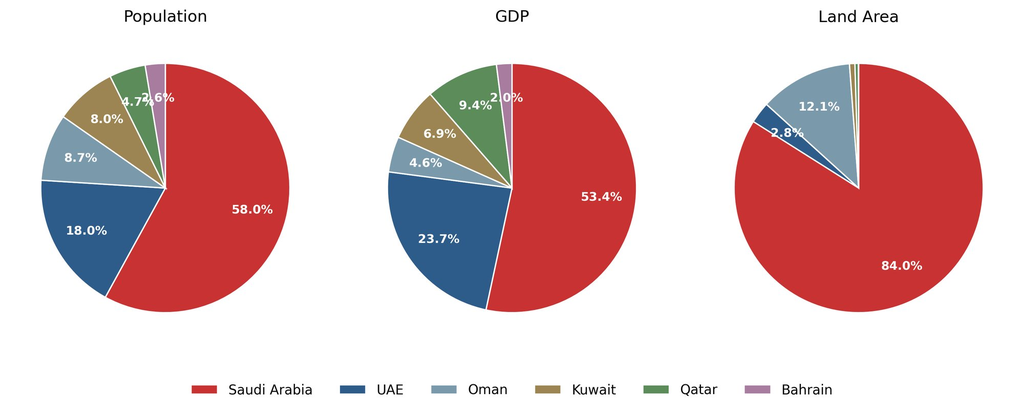

### 1.2.2 Coastal economies ringing the Persian Gulf

Geographically the six are a cluster of coastal economies ringing the Persian Gulf. Apart from Saudi Arabia and Oman, which have sizable interior hinterlands, the other four concentrate their population, capitals, and core economic activity along the coast. That narrow coastal belt leaves three shared imprints.

**Cities cluster along a thin coastal strip.** Saudi Arabia is vast in territory, yet its people gather in three corridors: inland Riyadh (the administrative center), the Dammam-Khobar belt on the east coast (the oil-industry zone), and the Jeddah-Mecca-Medina belt on the west coast (ports and religious centers). The capitals of the other five all sit on the coast: Abu Dhabi, Doha, Kuwait City, Manama, and Muscat. The GCC’s overall urbanization rate exceeds 85%, with Qatar and Kuwait near 100% and Bahrain around 90%, placing the bloc among the most urbanized regions on Earth.

**The Persian Gulf carries the GCC’s economic lifeline.** About 80% of GCC oil exports pass through the Strait of Hormuz, making this narrow channel a critical node of global energy security. Oman controls the Musandam Peninsula on the strait’s southern shore, and has long played mediator between Saudi Arabia and Iran. Any geopolitical tension over the strait transmits quickly into GCC fiscal accounts and foreign-exchange reserves.

**The climate is extreme.** Most of the GCC’s territory is tropical or subtropical desert, with summer temperatures routinely above 45°C and annual rainfall under 100 mm; the Empty Quarter (Rub’ al Khali) in the southern Arabian Peninsula covers roughly 650,000 km² and is almost uninhabited. The already-limited “habitable belt” runs on desalinated water and imported food.

Figure 2: The six GCC states and their coastal geography around the Persian Gulf

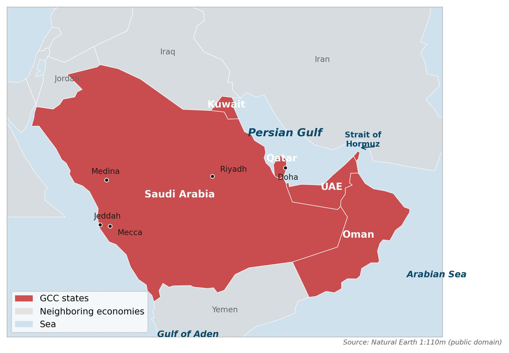

Note: the map is drawn from the public-domain Natural Earth 1:110m dataset (Natural Earth 2026).

### 1.2.3 Highly homogeneous political institutions

All six are hereditary monarchies (kingdoms, sultanates, or emirates). State assets are typically held and managed by the state or by state-owned bodies, but key appointments, strategic decisions, and fiscal allocation are highly concentrated in a state system led by the ruling family (Central Intelligence Agency 2023).

- **Single monarchies with highly concentrated executive power**: Saudi Arabia (King Salman bin Abdulaziz Al Saud, acceded 2015; Crown Prince Mohammed bin Salman, prime minister since 2022, commonly MBS), Oman (Sultan and Prime Minister Haitham bin Tariq, acceded 2020), and Qatar (Emir Tamim bin Hamad Al Thani, acceded 2013). Each has a basic law, written constitution, or consultative body, but final authority over cabinet appointments, national strategy, and fiscal and energy policy still rests with the monarch and the apparatus he appoints.
- **Parliamentary forms exist, but the ruling family still dominates the executive and legislative process**: Bahrain (Hamad bin Isa Al Khalifa, head of state since 1999, styled king since 2002) and Kuwait (Emir Mishal Al-Ahmad Al-Jaber Al-Sabah, acceded December 2023).
- **A federal monarchy**: the UAE. The hereditary rulers of seven emirates form the Federal Supreme Council; constitutionally the president and vice president are chosen by the Council, and the prime minister is appointed by the president with the Council’s approval. By convention the president is the ruler of Abu Dhabi (currently Mohamed bin Zayed Al Nahyan, MBZ), and the prime minister and vice president is the ruler of Dubai, Mohammed bin Rashid Al Maktoum (UAE Cabinet 2026; The Official Portal of the UAE Government 2026).

### 1.2.4 A dual structure of nationals and expatriates

Another defining feature of GCC demographics is that in four of the six, expatriate residents outnumber nationals; Saudi Arabia and Oman keep a national majority but still rely heavily on expatriate labor. GCC-Stat data for year-end 2024 show roughly 38.5M men and 22.7M women across the six, with men at 62.8%. This is no natural population structure; it is the result of large-scale, male-dominated labor migration (construction, energy, logistics, domestic work).

Table 3: Nationals vs. expatriates in the six GCC states (2024 estimates)

| Country | Nationals | Expatriates |
| --- | --- | --- |
| UAE | 12% | 88% |
| Qatar | 15% | 85% |
| Kuwait | 30% | 70% |
| Bahrain | 47% | 53% |
| Oman | 60% | 40% |
| Saudi Arabia | 58% | 42% |

Note: national shares combine published figures from each country’s statistics office with third-party estimates (Gulf Labour Markets and Migration Programme 2024); the official figures for Saudi Arabia, Kuwait, and Oman differ from this table by about 2-3 percentage points, and the UAE and Qatar publish no official national-population breakdown.

This dual structure distorts every “per capita” metric. The media’s “Qatar GDP per capita of $77,000” uses a denominator of about 2.86 million residents, yet only the roughly one-in-seven who are Qatari nationals qualify for tax-free status, housing support, free healthcare, and other citizen benefits. Use nationals as the denominator and “per-national” GDP jumps toward the half-million-dollar range.

This “statistical illusion” is the central issue as we move on to measure just how rich the GCC really is.

# 2 Measuring “just how rich”

Having sorted out the many meanings of “the Middle East” and narrowed the discussion to the six GCC states, the next step is to answer “just how rich.” Although “the Middle East is wealthy” is a widespread impression, it remains a vague one, short on concrete yardsticks and data. This section examines GCC wealth along three dimensions: **flow**, **stock**, and **structure**, moving from the GCC as a whole to individual countries and then to individual social strata, to build a full picture.

## 2.1 Flow metrics: as a bloc the GCC is the world’s 9th-largest economy

### 2.1.1 Aggregates: GDP and GNI (nominal / PPP)

By aggregate GDP and GNI, whether measured in nominal or PPP terms, **the GCC as a bloc sits steadily at 9th in the world**, on a par with Italy (nominal) or Indonesia (PPP). Its combined GDP is $2.33 trillion nominal and $4.33 trillion international dollars at PPP; GNI is $2.36 trillion nominal and $4.39 trillion at PPP. The PPP adjustment mainly reshuffles the global ranking itself (India, Russia, and Indonesia move up sharply), but the GCC’s relative position barely changes. Internally it is highly concentrated: Saudi Arabia alone accounts for 53% of the GCC total at nominal terms and 58% at PPP (World Bank 2026b, 2024).

Figure 3: The GCC’s aggregate standing in the world

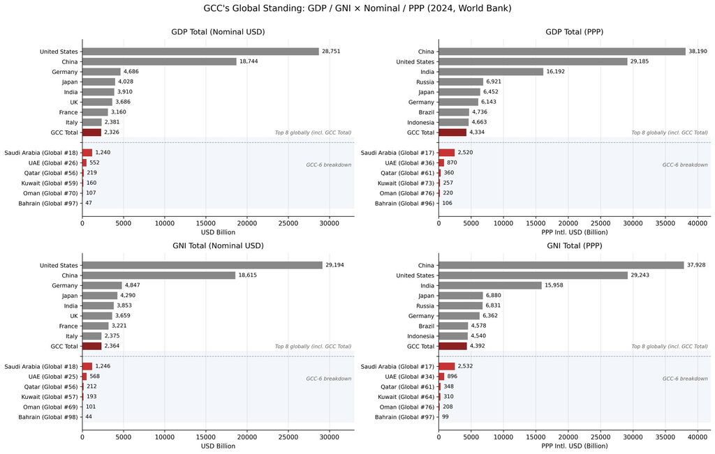

### 2.1.2 Per capita: a clear gradient inside the GCC

After the PPP adjustment, every GCC country’s ranking rises markedly (on the GDP measure, Saudi Arabia climbs 15 places and Bahrain 21, the largest moves; only Kuwait barely budges at +1). The mechanism is that local prices are pushed down by two forces: **energy subsidies** (Saudi gasoline runs about half the US price and a third of Germany’s), and **cheap expatriate labor** (construction, domestic, and retail wages are commonly one-fifth to one-tenth of those in advanced economies). Together these lift the GCC’s real purchasing power well above its nominal dollar income.

A per-capita lens also exposes an internal gradient at once. **Qatar** enters the global top 10 on all four per-capita measures, rising as high as 3rd in the world on GNI PPP; **the UAE** holds the second tier (global #16-#25); **Saudi Arabia, Bahrain, and Kuwait** form the third tier; and **Oman** is lowest (consistently in the #57-#65 band).

It bears emphasis that **the denominator in standard “per capita” measures is resident population (including expatriates), not nationals**. Expatriates make up 50%-90% of GCC residents, so both GNI and GDP per capita are heavily diluted; we adjust for this in later sections.

Figure 4: The GCC’s per-capita standing in the world: GDP / GNI × nominal / PPP (2024, World Bank)

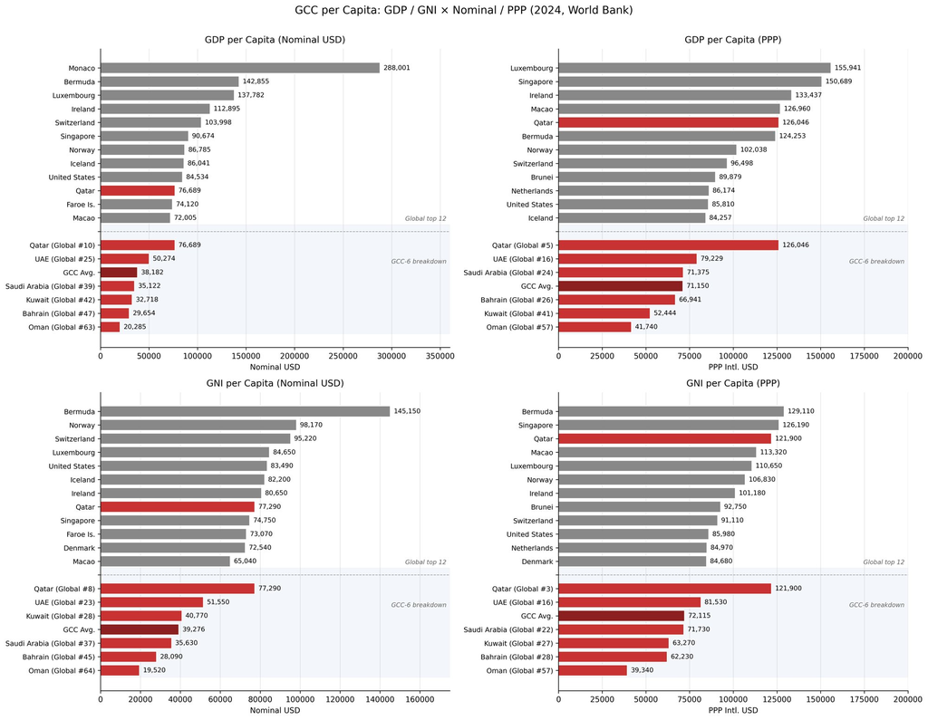

### 2.1.3 Section summary

Collapsing the global ranks on eight flow metrics into a single table makes the contrast between the six countries and “the GCC as a bloc” (aggregates summed, per-capita figures weighted by total population) plain. Three patterns stand out. The most direct: **as a bloc the GCC ranks a steady 9th in the world on all four aggregate measures**, sitting firmly among the first tier of “middle powers” (alongside Italy and Canada) when treated as a single economy. Next, **every GCC country rises sharply once PPP-adjusted**: Saudi Arabia gains 15 places and Bahrain 21 on the PPP measure, reflecting how energy subsidies and cheap expatriate labor depress local prices. Third, **Qatar** enters the global top 10 on all four per-capita measures, and reaches 3rd in the world on GNI PPP, behind only Bermuda and Singapore.

Table 4: Global ranks of the six GCC states and the GCC bloc on eight flow metrics (2024, World Bank)

| Indicator | Saudi | UAE | Qatar | Kuwait | Bahrain | Oman | GCC bloc |
| --- | --- | --- | --- | --- | --- | --- | --- |
| **Aggregate · GDP nominal** | 19 | 27 | 57 | 60 | 98 | 71 | **9** |
| **Aggregate · GDP PPP** | 18 | 37 | 62 | 74 | 97 | 77 | **9** |
| **Aggregate · GNI nominal** | 19 | 26 | 57 | 58 | 99 | 70 | **9** |
| **Aggregate · GNI PPP** | 18 | 35 | 62 | 65 | 98 | 77 | **9** |
| **Per capita · GDP nominal** | 40 | 25 | **10** | 43 | 48 | 64 | 36 |
| **Per capita · GDP PPP** | 24 | 16 | **5** | 42 | 27 | 58 | 25 |
| **Per capita · GNI nominal** | 38 | 23 | **8** | 28 | 46 | 65 | 29 |
| **Per capita · GNI PPP** | 23 | 16 | **3** | 28 | 29 | 58 | 22 |

Note: each cell is that country’s global rank on that measure (smaller is higher). The **GCC bloc** column treats the GCC as a single economy: aggregates are the sum of the six, reinserted into the 217-country list; per-capita figures are “GCC total ÷ GCC population” weighted values, then slotted into the global table. **Country ranks are positions after the GCC bloc is inserted** (so Qatar’s nominal-GDP #57 is the result of every country originally below #10 moving up one once the GCC bloc takes 9th place); the “global #N” shown in Figure 3 / Figure 4 is the original country rank without the bloc, one place different from this table. Qatar’s per-capita row is bolded to mark its global top-10 positions. Source: World Bank 2024 (GDP/GNI aggregates, per-capita PPP and nominal).

## 2.2 Stock metrics: as a bloc the GCC is the world’s largest set of sovereign investors

This section takes the two asset classes, sovereign wealth funds and central-bank reserves, in turn, asking how much wealth half a century of hydrocarbon surpluses has accumulated. The theoretically more comprehensive metric, NIIP (net international investment position), stays out of the main analysis because of GCC data gaps (no reliable official series for the UAE or Qatar), and appears only briefly at the end of §2.2.2.

### 2.2.1 Sovereign wealth funds: the GCC commands over $6 trillion

On Caproasia’s January 2026 “Top 127 Sovereign Wealth Funds” broad list (which includes pure sovereign funds, central-bank reserve portfolios, public pension funds, state-level funds, and state holding companies), **the six GCC states command about $6.15 trillion in SWF AUM**, more than any other single country grouping (China $3.76 trillion on a broad basis; Norway’s GPFG $2.00 trillion). **By total**, the UAE ranks second among single countries at $2.76 trillion; Saudi Arabia holds $1.78 trillion (global #4), Kuwait’s KIA $1.00 trillion (#7), and Qatar’s QIA $530 billion (#9).

Figure 5: The GCC’s sovereign wealth funds in the world: total vs. per capita (January 2026)

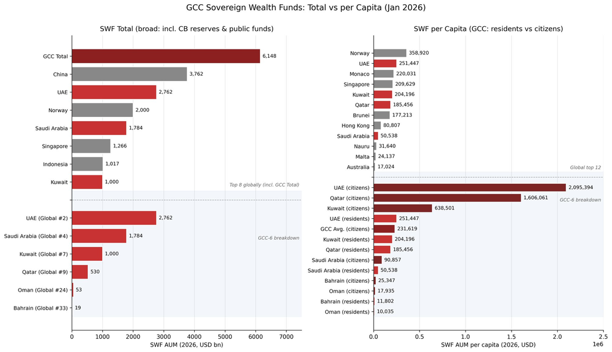

**Per capita requires two denominators.** By resident population, Norway leads the world at $359,000, the UAE is second at $251,000, Kuwait fifth at $204,000, Qatar sixth at $185,000, and Saudi Arabia ninth at $50,500. But for state assets, **nationals** are the more accurate denominator for “per-person ownership” (an SWF is managed by the state on behalf of its citizens and belongs to all of them). Because expatriates are a small share of Norway’s residents, its two measures are nearly identical; the GCC’s diverge wildly. **The GCC average per national is $232,000, third in the world**, 2.3 times the resident figure ($101,000) and about 65% of Norway’s. Recomputing each GCC country per national (a denominator swap only) gives roughly $2.09M per national for the UAE, $1.61M for Qatar, and $640,000 for Kuwait, all far above Norway.

Note: **Caproasia’s broad basis** includes vehicles such as ICD, Dubai World, and Sharjah Asset Management that are closer to sovereign holding companies than to pure SWFs; relative to narrower lists (Global SWF, SWFI) the totals run large and may include some liquidity reserves and domestic investments. **UAE sovereign funds are being restructured**: in January 2026 the former ADQ’s assets were folded into the newly created L’imad Holding Abu Dhabi, with some alternative-asset management passed to the independent Lunate (about $115 billion AUM); Mubadala and ADIA are also reshaping their external-investment platforms (Bloomberg 2026). These figures are as of January 2026, and the legal structures and fund attributions may shift further over the next year or two.

It bears noting that **SWF AUM is not the same as a state’s disposable net overseas wealth**. An estimated 60% of PIF’s assets are domestic (Aramco stakes, NEOM, and so on), so the portion that can be deployed flexibly abroad is far smaller than the headline figure (Global SWF 2026; International Monetary Fund 2025d). This differs markedly from the largely offshore portfolios of ADIA, KIA, and QIA.

### 2.2.2 Central-bank FX reserves: the GCC ranks 5th globally as a bloc

On World Bank 2024 data (including gold) (World Bank 2026b), **the GCC’s combined $829.8 billion ranks 5th in the world as a single economy**: ahead of India ($643.3 billion) and Russia ($608.4 billion), behind only China, Japan, the US, and Switzerland.

Per capita again splits two ways. By resident population (the global-ranking basis), Switzerland leads at $101,000, with the UAE 6th at $21,700 per person, Qatar 8th at $18,900, Saudi Arabia 14th at $13,100, and Kuwait 16th at $10,400. **By nationals**, the UAE’s $180,500 per person and Qatar’s $163,600 both far exceed Switzerland. Reserves are a liquidity buffer the state manages on behalf of its citizens, so the national denominator better reflects per-person defensive capacity.

Figure 6: The GCC’s central-bank FX reserves in the world: total vs. per capita (2024, World Bank WDI)

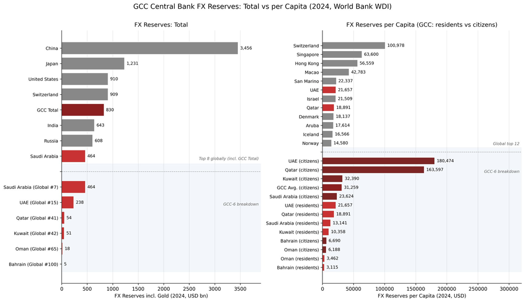

On the international-comparison front, **NIIP (the net international investment position)**, residents’ external assets minus liabilities, is another important gauge of a country’s external financial stock. But the GCC’s data gaps here are severe, so this section **runs no separate global ranking on NIIP**. One directional fact is worth keeping in mind: Oman is the only GCC state openly in a net external-liability position (external debt exceeds SWF plus reserves), while the others are generally large net creditors.

### 2.2.3 Section summary

Placing flow against stock, the GCC’s **“stock over flow”** character is striking. Caproasia’s broad SWF measure already includes some central-bank reserve portfolios and so overlaps with the reserves measure, meaning the two should not be simply added; but even on the conservative SWF figure alone, the GCC’s $6.15 trillion equals 264% of GCC GDP, one of the highest ratios in the world (well above the G7 average of 30%-50%). In other words, much of GCC wealth has already been realized as stock.

Table 5: Global ranks of the six GCC states and the GCC bloc on four stock metrics (2024-2026; per capita on resident population)

| Indicator | Saudi | UAE | Qatar | Kuwait | Bahrain | Oman | GCC bloc |
| --- | --- | --- | --- | --- | --- | --- | --- |
| **SWF · total** | 4 | **2** | 9 | 7 | 33 | 24 | **1** |
| **SWF · per capita** | 9 | **2** | **6** | **5** | 14 | 15 | 8 |
| **Reserves · total** | **7** | 15 | 41 | 42 | 100 | 65 | **5** |
| **Reserves · per capita** | 14 | **6** | **8** | 16 | 53 | 47 | 13 |

Note: **per-capita basis**: both country and GCC-bloc per-capita figures use resident population (consistent with the global rankings and with Figure 5 / Figure 6). **Country ranks** are positions on the global table without the GCC bloc; the **GCC bloc** column is the position obtained by inserting the GCC as a single economy (totals are the sum of the six, per capita weighted on the resident basis). SWF uses Caproasia’s broad 2026 Top 127; reserves use World Bank WDI 2024 (including gold).

## 2.3 Structural view: a clear social hierarchy of wealth

The GCC’s total population is about 60.9 million, of whom roughly 26.5 million (44%) are nationals and 34.4 million (56%) expatriates; in the UAE and Qatar expatriates reach 88%, so nationals are a minority in their own country. The per-capita GDP computed earlier, spreading GDP across all 60-odd million residents, puts a migrant worker earning a few hundred dollars a month and a fabulously wealthy royal under the same denominator, reflecting neither the former’s circumstances nor the latter’s true economic standing.

### 2.3.1 Method

- `aptinc_pXXp100_992_j`: equal-split adult average pre-tax national income (including capital gains, implied SWF distribution, and all other NI allocations within the DINA framework)
- `adiinc_pXXp100_992_j`: equal-split adult average post-tax disposable income (pre-tax income less personal income tax and social contributions, plus cash transfers; excludes in-kind services)

### 2.3.2 Comparing Top 1% / 10% / 20% incomes

The table below lists average adult per-capita income for the Top 1%, Top 10%, and Top 20% across 16 countries, with pre-tax and post-tax side by side, in PPP dollars, 2022-calibrated. The Top 1% captures the elite; the Top 10% is the common “upper class” benchmark; the Top 20% takes in the upper-middle class.

Table 6: GCC vs. major G7 / OECD reference countries: tercile pre-tax + post-tax comparison (USD PPP, 2022-calibrated)

| Country | Top 1% pre-tax | Top 1% post-tax | Top 10% pre-tax | Top 10% post-tax | Top 20% pre-tax | Top 20% post-tax |
| --- | --- | --- | --- | --- | --- | --- |
| Qatar | 2,439,000 | 2,263,000 | 568,000 | 543,000 | 354,000 | 343,000 |
| UAE | 1,405,000 | 1,371,000 | 427,000 | 420,000 | 276,000 | 273,000 |
| Saudi Arabia | 1,861,000 | 1,852,000 | 418,000 | 415,000 | 269,000 | 266,000 |
| Bahrain | 1,752,000 | 1,728,000 | 396,000 | 390,000 | 243,000 | 239,000 |
| Kuwait | 1,288,000 | 1,278,000 | 330,000 | 328,000 | 217,000 | 216,000 |
| United States | 1,840,000 | 1,273,000 | 416,000 | 326,000 | 274,000 | 226,000 |
| Norway | 997,000 | 808,000 | 321,000 | 275,000 | 240,000 | 210,000 |
| Oman | 969,000 | 940,000 | 274,000 | 268,000 | 173,000 | 171,000 |
| Germany | 998,000 | 770,000 | 283,000 | 230,000 | 197,000 | 165,000 |
| Canada | 859,000 | 650,000 | 262,000 | 207,000 | 188,000 | 155,000 |
| United Kingdom | 965,000 | 683,000 | 262,000 | 204,000 | 184,000 | 150,000 |
| Switzerland | 913,000 | 527,000 | 276,000 | 199,000 | 202,000 | 158,000 |
| Japan | 634,000 | 504,000 | 218,000 | 183,000 | 136,000 | 119,000 |
| South Korea | 764,000 | 644,000 | 205,000 | 182,000 | 145,000 | 132,000 |
| France | 812,000 | 480,000 | 231,000 | 158,000 | 165,000 | 123,000 |
| Italy | 541,000 | 421,000 | 189,000 | 158,000 | 138,000 | 120,000 |

Note: **Source**: the six value columns come directly from the WID API (variables `aptinc_p99p100_992_j` / `adiinc_p99p100_992_j` / `aptinc_p90p100_992_j` / `adiinc_p90p100_992_j` / `aptinc_p80p100_992_j` / `adiinc_p80p100_992_j`, in WID’s default “constant local currency, 2024 prices”), converted to PPP USD using the same-year `xlcusp` PPP rate; zero self-built assumptions. **GCC caveat**: WID’s direct micro surveys run only to 2014 (Saudi 2008, Oman 2010, UAE 2009, Qatar 2012, Kuwait 2013, Bahrain 2015), with later years extrapolated under (Alvaredo et al. 2019)’s regional interpolation and oil-rent allocation assumptions, leaving the absolute values with a ±20-30% uncertainty band; the OECD side draws on the same WID series to keep the basis consistent. The table is sorted descending on the “Top 10% post-tax” column, to read off the most common benchmark of “take-home” differences directly. The full two-basis × tercile × multi-year wide table (with tax-wedge columns) sits in data/s2-3_top_deciles_combined.csv.

### 2.3.3 Three directional findings

The most immediate is the gulf created by taxation. None of the six GCC states levies personal income tax on employment income (Oman’s PIT law is on the books and will apply a 5% rate to income above OMR 42,000 from 2028), whereas the OECD’s single-worker average “tax wedge” was 35.1% in 2025 and top combined effective rates run 22%-38% (OECD 2026; PwC 2026). From pre-tax to post-tax for the Top 10%: France $231K → $158K (−31%), Switzerland $276K → $199K (−28%), the US/UK/Canada about −22%, the Nordics 14%-19%; on the GCC side Kuwait and Saudi Arabia below 1%, Bahrain/UAE/Oman 1%-2%, Qatar 4%. This single mechanism is enough to move the GCC top tier up a notch on a “take-home” basis: the US Top 10% post-tax of $326K sits level with Kuwait’s $328K (a gap of just $2K), below Qatar’s $543K, the UAE’s $420K, Saudi Arabia’s $415K, and Bahrain’s $390K, landing between Norway’s $275K and the GCC mid-pack.

The Top 1% sharpens the divergence. Qatar’s elite take home $2.26M PPP, 1.8 times the US’s $1.27M; Saudi Arabia, Bahrain, the UAE, and Kuwait all fall in the $1.28-1.85M range, every one above the US. The rest of the G7 / OECD cluster at $0.42-0.81M, leaving the GCC elite in a tier of their own on a take-home basis.

The Top 20% paints a different picture. At this wider percentile, Qatar still leads at $343K, but the US’s $226K slots into the rest of the GCC mid-pack (UAE $273K, Saudi Arabia $266K, Bahrain $239K, Kuwait $216K, Oman $171K), nearly overlapping the higher OECD countries (Norway $210K). The Top 20% band already mixes in a fair number of mid-level professional expatriates (doctors, engineers, teachers) who do not receive citizen benefits, pulling the per-capita level down.

### 2.3.4 Mapping the three-tier pyramid onto the percentiles

Projecting the percentile comparison back onto the GCC’s internal three-tier structure reveals a natural mapping between percentiles and population layers.

Figure 7: Schematic of the GCC wealth pyramid: headcount rises top to bottom, per-person wealth falls top to bottom

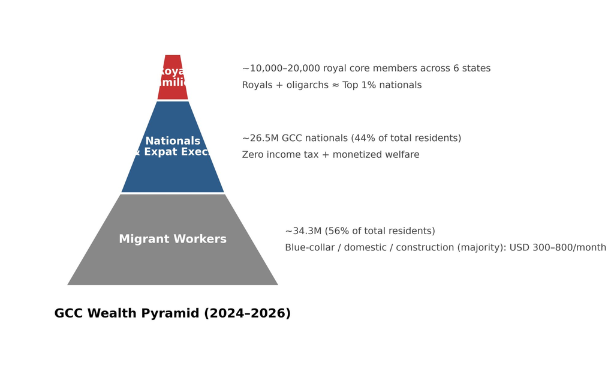

**Top tier ≈ Top 1% (the extended royal circle + top oligarchs).** All six GCC states are monarchies, and the Top 1% percentile captures the extended royal circle plus top business oligarchs (Qatar $2.44M, Saudi Arabia $1.86M, Bahrain $1.75M, the UAE $1.40M, Kuwait $1.29M, Oman $0.97M average adult per capita, PPP pre-tax). The personal wealth of core royals is missing from public statistics; market composite estimates place them among “the world’s richest families” (VnExpress 2024; Arab News 2025).

**Middle tier ≈ Top 10%-50% (nationals + expatriate professionals).** The national population (about 26.5 million) sits roughly between the Top 10% and Top 50%. Senior government employees, managers at royal-linked firms, and senior professionals make up the bulk of the Top 10%; ordinary nationals, supported by zero income tax, housing plots, education and healthcare subsidies, public-sector hiring priority, and energy subsidies, sit overall in the Top 20%-50%.

**Bottom tier ≈ below the Top 50% (expatriate workers).** Expatriate workers (about 34.4 million, 56%) concentrate below the Top 50%. Ordinary blue-collar workers (construction, domestic, retail, mostly from South Asia) earn $300-800 a month (Migration Policy Institute 2024; ILO 2020). The GCC is the world’s largest remittance-sending region, with over $100 billion in 2024 (about 4-5% of GCC GDP).

Taken together, **the GCC is a distinctive form of wealth: not a counterpart to the G7 but a separate species, one in which realized stock dominates.** On the “realized wealth” dimensions (flow, stock, and citizen disposable income) it stands at the global frontier, and the disposable income of nationals in the richest GCC states ranks at the very top in the world. That raises a fresh research question: how tightly is the GCC’s wealth-creation capacity tied to oil, and if oil revenue were to fall sharply, how long could the GCC wealth story continue? We turn to these questions in the sections that follow.

# 3 Why so rich: the causal chain from oil to wealth

The previous section reviewed the flow and stock of GCC wealth; this one tries to answer why the GCC is so rich. As wealthy oil producers, the starting point is naturally oil.

## 3.1 It all starts with oil

**The GCC is one of the world’s most important hydrocarbon clusters.** Per the Energy Institute’s *Statistical Review of World Energy 2024*, the six GCC states hold combined proven oil reserves of about 510 billion barrels, of which Saudi Arabia alone holds 267 billion barrels, second in the world (behind only Venezuela); the UAE’s 111 billion barrels rank 6th and Kuwait’s 102 billion rank 7th. Gas reserves center on Qatar’s 24 trillion cubic meters (3rd in the world, behind Russia and Iran), with Saudi Arabia at 8.3 tcm, the UAE 5.9, Kuwait 1.7, Oman 0.6, and Bahrain 0.1; the GCC together holds about 21% of the world’s proven gas reserves. Combining oil and gas on an oil-equivalent (heat-content) basis, **the six GCC states hold about 768 billion barrels of oil equivalent, 27.5% of the world’s proven hydrocarbon reserves**. On output, by the IMF’s production measure, the GCC accounts for about one-fifth of global oil and gas production (Mirzoev et al. 2020).

Oil’s grip on the GCC economy does not end at the first layer of wells and refineries. Oil revenue first enters the state accounts as fiscal revenue, then flows back into the so-called “non-oil” sector via government wages, price subsidies, public projects, and the domestic investments of sovereign funds. We examine oil’s impact on the GCC economy from two angles: a **share view** (hydrocarbon rents as a share of GDP, and oil & gas revenue as a share of government revenue) and an **elasticity view** (how much a 1% change in oil prices moves GDP).

Figure 8: The world’s top 15 hydrocarbon-resource countries (year-end 2023)

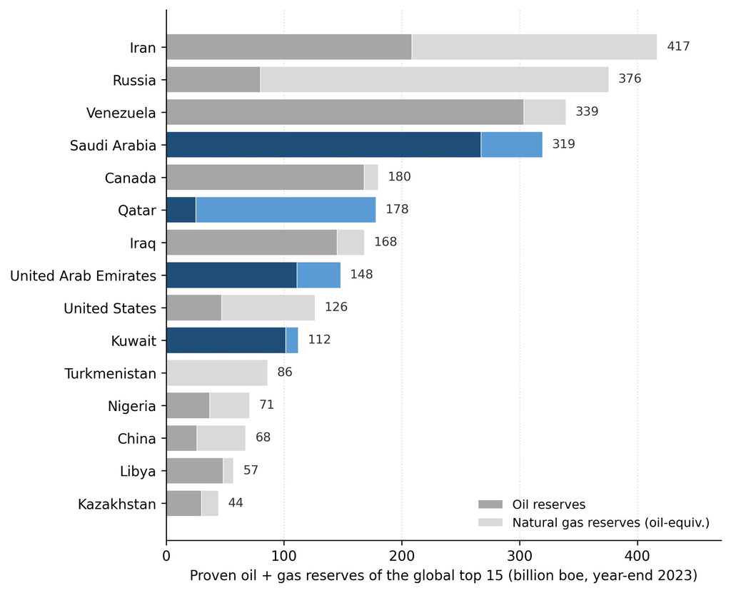

Note: the world’s top 15 hydrocarbon-resource countries ranked by proven reserves at year-end 2023 (Energy Institute 2024); oil and gas combined on the standard heat-content basis of 1 trillion cubic meters ≈ 6.29 billion barrels of oil equivalent (boe); GCC countries highlighted in blue, others in gray. Full data in data/s3-1_global_hydrocarbon_reserves.csv.

### 3.1.1 Share view: hydrocarbon rents as a share of GDP have fallen sharply, but oil & gas still fund 30%-90% of government revenue

Start with oil and gas’s contribution to the whole economy. Here we use the World Bank’s **“oil and gas rents as a share of GDP”** indicator (World Bank 2026c). Its definition takes the total value of hydrocarbon output at world market prices, **subtracts all production costs**, and the remainder, the “economic rent” the resource delivers to the economy that year, is divided by nominal GDP to give a percentage. **The higher the percentage, the more dependent the economy is on hydrocarbons.**

Figure 9: The evolution of hydrocarbon rents as a share of GDP across the GCC (2010-2021, World Bank)

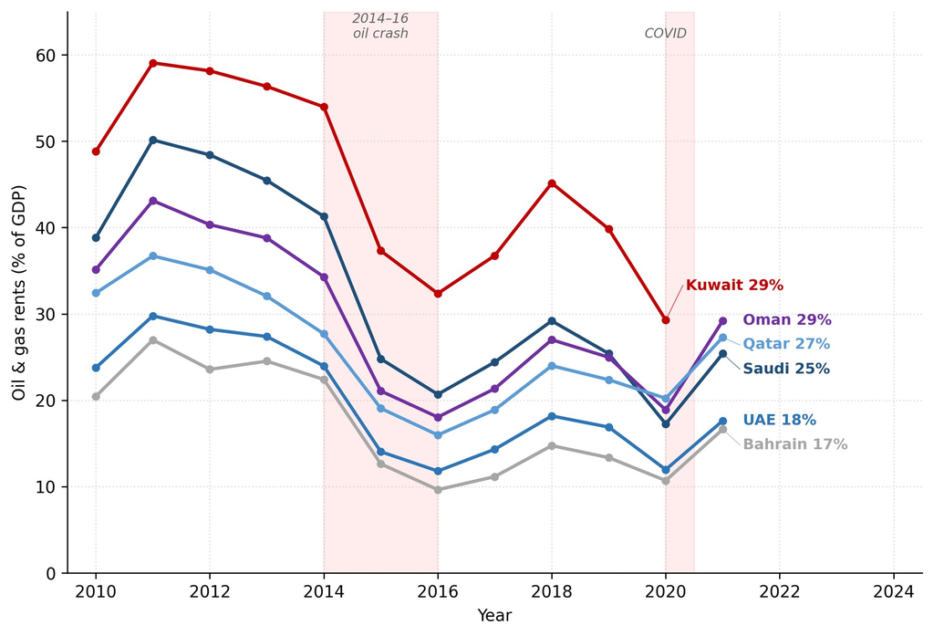

Note: time series of hydrocarbon rents as a share of GDP for the six GCC states, from World Bank Open Data indicators NY.GDP.PETR.RT.ZS (oil) + NY.GDP.NGAS.RT.ZS (gas). The pink bands mark the two external shocks: the 2014-16 oil-price crash and the 2020 COVID shock. Kuwait’s 2021 data point is missing, so its last point is 2020; the other five run to 2021. Some end-of-line labels are vertically offset because the values sit close together. Full data in data/s3-1_oil_gas_rents_pct_gdp.csv.

Now turn to oil and gas as a share of government revenue. The government’s hydrocarbon revenue here means the cash the state collects from the sector: royalties, corporate income tax, and dividends from state oil-and-gas companies. On IMF data, GCC fiscal dependence on hydrocarbons splits into three clear tiers. **The first tier** is Kuwait, Qatar, and Oman, where oil and gas still supply over 60% of fiscal revenue; Kuwait is the most extreme, with non-oil tax revenue at just 5% of GDP and the budget almost entirely propped up by hydrocarbons. **The second tier** is Saudi Arabia, whose hydrocarbon dependence fell from 85% in 2014 to about 65% in 2024, driven mainly by the non-oil revenue that Vision 2030 expanded (a 15% VAT, visa reforms, and the like). **The third tier** is the UAE alone, where federal-level hydrocarbon dependence is only about 30%-40%, though this mainly reflects Dubai; looking at the Abu Dhabi emirate alone, oil and gas still account for about 70% of its fiscal revenue.

Table 7: GCC fiscal dependence on hydrocarbons: a three-tier split

| Country | Oil & gas, % of fiscal revenue (2024-25) | Oil & gas, % of exports |
| --- | --- | --- |
| Kuwait | 85-90 | 90+ |
| Qatar | 75-80 | 85+ |
| Saudi Arabia | 60-70 | 70+ |
| Oman | 60-70 | 65+ |
| Bahrain | 50-65 | 70 |
| UAE | 30-40 | 35 |

Note: **Source**: integrated from the IMF GCC Policy Paper 2024 and each country’s latest Article IV reports (International Monetary Fund 2024, 2025d, 2025e, 2026, 2025b, 2025a), mostly 2024 actuals or 2024-2025 staff projections; ranges are used because different IMF reports occasionally make small revisions to the same year, and because federal- and emirate-level figures differ for some countries.

Taking the two indicators together, the GCC economy is indeed becoming more diversified, but the diversification of government revenue lags far behind: much of the non-oil GDP growth (tourism, real estate, services) has not turned into stable tax revenue. To quantify GCC dependence on hydrocarbon revenue, two further IMF-standard metrics help: the **fiscal break-even oil price** (BEOP) and the **non-oil primary balance** (NOPB).

The **fiscal break-even oil price** (BEOP) is the Brent price that would bring a country’s overall fiscal balance exactly to zero in a given year. On IMF data, **the GCC’s weighted-average BEOP rose to $83.2/bbl in 2024**, about $10 higher than in 2020, mainly because each country’s Vision strategy pushed up public investment spending (Alby 2025). Country differences are vast: **Qatar (about $45), the UAE ($54 in 2024), and Oman ($55) are lowest** (see the IMF Article IV reports (International Monetary Fund 2025e, 2025a)); **Saudi Arabia is about $94 in 2025**, second from the bottom precisely because of Vision 2030’s heavy investment intensity; **Kuwait is about $80** (on a budget basis, before counting its SWF investment income); and **Bahrain is highest at about $130** (a structural trade deficit plus a heavy public-debt burden).

The **non-oil primary balance** (NOPB) is non-oil revenue less interest spending, as a share of non-oil GDP. On IMF data, every GCC country’s NOPB is currently negative; the 2024 deficits are: **Kuwait −64%, Qatar −33%, Saudi Arabia −32%, Oman −28%, the UAE −18%, Bahrain −16%**. This shows the GCC’s fiscal revenue structure remains heavily dependent on hydrocarbons, and that non-oil growth has not become a stable tax base for government. GCC fiscal sustainability still hinges largely on the stability and persistence of hydrocarbon revenue.

### 3.1.2 Elasticity view: a 1% move in oil prices shifts GCC nominal GDP by 0.4%-0.6%

On the sensitivity of GCC GDP to oil prices, a large empirical literature puts the oil-price-GDP elasticity mostly in the 0.4-0.6 range (Mohaddes and Pesaran 2016; Berument et al. 2010; Cherif et al. 2014). That means a 1% change in oil prices moves GCC nominal GDP by 0.4%-0.6%. Take Saudi Arabia: a 50% drop in oil prices, at an elasticity of 0.4-0.6, could cut nominal GDP by 20%-30%. But the earlier indicators put the oil sector at about 25% of GDP, so 12.5% of the GDP evaporation is explained by the direct hydrocarbon sector, and the remaining 7.5-17.5 percentage points come from the “non-oil” sector, which means much of that nominal non-oil GDP is in fact a “second circulation” of oil (the downstream derivatives of government wages, subsidies, and public procurement).

Extending that inference, GCC GDP splits into three layers. The bottom is the **direct hydrocarbon layer**: crude, gas, petrochemicals, and refining, directly sensitive to oil prices. The middle is the **second-circulation layer**, the non-oil sector driven by hydrocarbon-funded fiscal spending (government wages, infrastructure, real estate, domestic retail), much of which would struggle to survive without oil. Citi’s March 2026 disaggregation of the GCC non-oil economy confirms the substance of this layer: in Saudi Arabia, wholesale-retail, food service, and hotels make up 17% of core non-oil value added, but “mostly domestic retail rather than tourism,” and domestic retail demand is itself sourced from government wages and energy subsidies (Domac and Isiklar 2026a). The top is the **native non-oil layer**, oriented to global markets or genuine local private demand, such as Dubai’s entrepôt trade, financial services, high-end tourism, and logistics hub.

For now, only the UAE has built a scaled native non-oil layer, via the Dubai model, but **the direction of diversification does not necessarily lower risk**. Citi’s two 2026 GCC notes point out that the GCC’s diversification over the past two decades concentrated in aviation, tourism, logistics, conventions, and real estate. These sectors did reduce direct hydrocarbon dependence, but they also increased exposure to geopolitical conflict, airspace closures, and expatriate-population flows (Domac and Isiklar 2026b), creating a new diversification dilemma.

## 3.2 More than oil

Oil created the GCC states’ immense wealth, but the GCC is not the only oil producer. In 2024, the countries where hydrocarbon exports exceeded 50% of GDP also included Iran, Iraq, Venezuela, Nigeria, Angola, and Algeria; they sit on equal or larger oil fields, yet none of them turned oil into long-accumulated national wealth the way the GCC did. So what lets the GCC convert oil into sustainable wealth?

Answering this requires two layers. The first is the **national-level conditions for success**: which conditions set the GCC apart from other oil producers and let the petrodollars accumulate stably into SWFs and reserves. The second is the **domestic distribution mechanism**: what institutional arrangements behind the three-layer wealth picture (royals, citizens, expatriate workers, sketched in §2.3) keep it running stably. Together these two layers form the full operating logic of the GCC “rentier state”; the last part of this section returns to the academic framework for a summary, and connects to §4’s forward-looking analysis of “how long can this mechanism hold.”

### 3.2.1 National level: political stability, the dollar alliance, early SWFs, and the population-to-resource ratio

**First, half a century of political continuity.** Saudi Arabia’s House of Saud has ruled continuously since 1932; the UAE’s ruling families (Al Nahyan, Al Maktoum, and others) since the 1971 federation; Kuwait’s Al Sabah since 1752; Qatar’s Al Thani since 1825; Bahrain’s Al Khalifa since 1783; and Oman’s Al Said since 1744. None of the six royal houses has experienced a substantive change of regime in the past 50 years. This continuity is precisely what the failed oil-producer cases generally lack: Iran’s 1979 Islamic Revolution, Libya’s 1969 coup, and Iraq’s regime changes in 1958 and 2003 all came with the zeroing-out or resetting of accumulated wealth. Venezuela’s Chávez political reforms from 1999 spent the fiscal surpluses of the oil-price peak on consumer-price subsidies rather than savings; the currency lost 99.999997% of its value over 1998-2018, cumulative GDP fell 75-88% over 2014-2021, and the Institute of International Finance called it “the largest economic collapse outside of war in 45 years” (Council on Foreign Relations 2026a).

**Second, deep integration with the US security architecture.** Saudi Arabia allowed US troops to be stationed from 1991; the UAE hosts Al Dhafra Air Base; Qatar’s Al Udeid is the most important overseas forward base of US Central Command; and Bahrain is home to the US Fifth Fleet. This security alliance has concrete economic meaning: it lets GCC petrodollars flow stably into the dollar settlement system, and lets SWF assets keep being allocated across global capital markets in dollar-denominated form. By contrast, Iran, Venezuela, and Russia, even with oil-and-gas income, cannot stably convert it into globally deployable portfolios in developed markets.

### 3.2.2 The distribution mechanism: stable transfer of wealth across three tiers

§2.3 sketched the GCC’s “three-tier pyramid” (see Figure 7), with royals at the top, citizens in the middle, and expatriate workers at the bottom. The stable distribution across the three is no accidental social structure but the product of three interlocking legal and political mechanisms.

**The top tier is the constitutional fact of “the state as family.”** The GCC’s monarchies are not metaphor but legal arrangement. The Saudi king, for instance, is simultaneously head of state, head of government, and commander of the armed forces, and the ultimate decision-maker for PIF is the crown prince directly. That means discussing the GCC’s $6.15 trillion in SWFs and $829.8 billion in reserves is, in essence, discussing wealth managed by six royal families through the state apparatus. Saudi Arabia’s 2017 “anti-corruption” campaign was the most direct expression of this logic: the crown prince, Mohammed bin Salman, used it to re-concentrate wealth scattered among various royal members under PIF, completing the re-integration of “power, wealth, and sovereign fund.”

**The middle tier is the “depoliticized exchange” of the rentier state.** Mahdavy (1970) and Beblawi (1987) argued that when a state’s fiscal revenue comes mainly from external resource rents rather than domestic taxation, the relationship between state and citizen becomes one-way (the state delivers welfare, citizens pay no tax) rather than two-way (citizens pay tax in exchange for services), and citizens accordingly forgo “no taxation without representation,” the core political demand of the modern fiscal state. The GCC has landed this logic on four concrete institutions: **zero income tax** (the exception being Oman’s 2025 law applying a 5% tax to income above OMR 42,000 from 2028), **public-sector hiring priority** (Hertog 2019 shows empirically that GCC nationals earn 1.5-4 times more in the public sector than expatriate workers in the private sector (Hertog 2019)), **comprehensive subsidies for housing, fuel, education, and healthcare** (inherited from the resource ownership tied to citizenship, not public services exchanged for taxes), and **the exclusivity of welfare tightly bound to citizenship**.

Academic assessment of the rentier-state model is sharply divided. **The pessimists** treat the rentier state as a long-run drag on development: even if rich in the short run, it eventually fails on structural problems such as weak innovation, low female labor participation, and fragile institutions. Karl (1997), in *The Paradox of Plenty*, argued that the more hydrocarbon-rich a country, the lower its long-run growth, because “Dutch disease” crushes manufacturing, fiscal dependence on rents leaves the government unaccountable to taxpayers, and easy wealth fuels rent-seeking and corruption (Karl 1997). Ross (2012), in *The Oil Curse*, used large-sample regressions to show that oil revenue raised the stability of authoritarian institutions, lowered female labor participation, and lowered the probability of democratic transition (Ross 2012). Sachs and Warner’s (1995) earlier cross-country regressions likewise found resource wealth negatively correlated with growth (Sachs and Warner 1995).

**The optimists** treat the rentier state as a peculiar but stable political-economic equilibrium. Hertog and colleagues (2019), in the LSE-led POMEPS Studies 33, focused on the evolution of the GCC rentier state (Hertog 2019), arguing that the GCC’s success is not that it dodged the “resource curse” but that, through SWFs + citizen welfare + monarchical continuity, it converted the “resource curse” into a “resource stabilizer”: hydrocarbon surpluses accumulate in SWFs, citizens receive a “dividend” via the welfare package, and the royal family exchanges that for political stability. Cherif, Hasanov, and Zhu (2014) caution that this stability depends heavily on sustained hydrocarbon revenue: the GCC’s diversification over recent decades occurred mainly in non-tradable sectors (services, construction) and failed to create a genuinely high-productivity export sector independent of hydrocarbons (Cherif et al. 2014).

This disagreement cannot be fully settled with existing data; it awaits the empirical test of a “post-oil era” (if one arrives). But the disagreement itself points to the core fragility of the rentier-state model: it assumes the state can keep extracting rents of sufficient scale from the outside. If oil revenue falls significantly, the state will be forced to choose among three options: cut welfare (breaking the implicit “dividend” promise and shaking citizens’ political support for the monarchy), expand taxation (opening political space for “no taxation without representation” and challenging the monarchy’s fundamental architecture), or raise the burden on expatriate residents and businesses (workable in the short run, but damaging the GCC’s appeal as a global hub for talent and capital). Oman’s 2025 5% income-tax law is early empirical evidence of this fragility: low-rate and narrow as it is, it has institutionally introduced a fulcrum that could, over the long run, lead to political-structural change. Whether this change spreads will depend on the future trajectory of hydrocarbon revenue and the evolution of geopolitical shocks.

## 3.3 Looking ahead: geopolitical conflict and the energy transition

### 3.3.1 Recent conflict: the UAE is most exposed, Oman relatively benefits

This section focuses on the US-Iran conflict that erupted on 28 February 2026 and its transmission to the GCC economy, drawing directly on the recent reports the IMF, Citi Research, AGSI, and others published in March-April 2026. These analyses point out that the most diversified GCC economies are, under a geopolitical shock, the most fragile: the UAE rather than Qatar is the most severely affected GCC state, because open services (aviation, tourism, logistics, retail) are far more exposed to geopolitical risk than a pure oil economy.

Citi Research’s two March 2026 notes proposed a **Conflict-Sensitive Sectors (CSS) index**, grouping the conflict-exposed non-oil sectors into three categories: wholesale-retail / food service / hotels (WRTRH, capturing retail, lodging, tourism), transport / storage / communications (TSC, capturing aviation, shipping, logistics), and construction (CON, capturing investment, foreign capital, project pipelines) (Domac and Isiklar 2026a). What these three share is that their demand or supply chains are directly exposed to security shocks: airspace closures, shipping delays, tourism stoppages, and suspended foreign-funded projects all hit output immediately. On a total-value-added (TVA) basis, 2024 CSS shares range from **Kuwait 15.5%, Bahrain and Oman about 24%, Qatar 29.5%, Saudi Arabia 31%, to the UAE 36% (rising to 44% on a core-non-oil-VA basis)**. This distribution reveals the **“diversification paradox”**: the more successfully the GCC diversifies into services like aviation, tourism, logistics, conventions, and real estate, the more fragile it becomes under a geopolitical shock.

Combining the CSS supply-side measure with demand-side measures (private consumption as a share of GDP, government consumption as a share of GDP, tourism’s direct GDP contribution), Citi’s country vulnerability ranking makes an important correction to intuition. **The UAE is most severely hit**: CSS 36%, private consumption 64% of GDP, tourism and business contributing 13% of GDP, the highest open-services exposure, and a domestic market too small to absorb it. **Qatar** has the highest hydrocarbon-route exposure, with extreme LNG and Ras Laffan concentration, but private consumption is only 25% of GDP, a clear demand-side buffer, so the total shock falls mainly on the hydrocarbon supply side. **Saudi Arabia** is in the middle, CSS 31%, with the domestic market and government consumption providing some buffer and part of its routes able to bypass Hormuz. **Kuwait**’s small non-oil economy actually lowers its services exposure, but the over-concentration of its hydrocarbon export route is another kind of fragility. **Bahrain**, CSS 24% with debt over 130% of GDP, is tourism- and finance-sensitive with the weakest fiscal space. **Oman relatively benefits**: its coastline lies beyond Hormuz, and the port of Duqm, as an Indian Ocean export hub, becomes a relatively safe alternative node under the current situation.

# 4 Conclusion

The six GCC states are the Middle East’s “rich club.” By flow, the six had combined nominal GDP of about $2.33 trillion in 2024, 9th in the world, with PPP GDP per capita of $71,000; by stock, the six command combined SWF AUM of about $6.15 trillion, more than any other single country grouping. GCC wealth was formed with oil as the necessary condition plus four sufficient conditions present at once: more than half a century of monarchical political continuity, deep integration with the US security architecture, the early-sovereign-fund mechanism, and a favorable population-to-resource ratio. Domestically, stable distribution is achieved through legal and institutional mechanisms such as “the state as family,” “no tax in exchange for quiet,” and “Kafala exclusivity.” On the whole, GCC wealth is a realized stock advantage layered on a still-running hydrocarbon flow, and its long-run sustainability ultimately depends on the pace of falling hydrocarbon demand, the speed of the GCC’s asset transition, geopolitical conflict, and other forces.

## References

Adelson, Roger. 1995. *London and the Invention of the Middle East: Money, Power, and War, 1902–1922*. Yale University Press.

Alby, Stéphane. 2025. *Gulf States: Falling Oil Prices Should Not Pose a Threat to Economic Diversification*. BNP Paribas Economic Research. https://economic-research.bnpparibas.com/Views/DisplayPublication.aspx?type=document&IdPdf=51600.

Alvaredo, Facundo, Lydia Assouad, and Thomas Piketty. 2019. “Measuring Inequality in the Middle East 1990–2016: The World’s Most Unequal Region?” *Review of Income and Wealth* 65 (4): 685–711. https://doi.org/10.1111/roiw.12385.

Arab News. 2025. *Saudi Arabia Has Highest Number of Arab Billionaires: Forbes*. https://www.arabnews.com/node/2595776/business-economy.

Berument, M. Hakan, Nildag Basak Ceylan, and Nukhet Dogan. 2010. “The Impact of Oil Price Shocks on the Economic Growth of Selected MENA Countries.” *The Energy Journal* 31 (1): 149–76.

Bloomberg. 2026. *Abu Dhabi to Consolidate Wealth Fund ADQ, L’imad Assets*. https://www.bloomberg.com/news/articles/2026-01-30/abu-dhabi-to-consolidate-wealth-fund-adq-l-imad-assets.

Central Intelligence Agency. 2023. *The World Factbook (2023 Archive): Government Type*. https://www.cia.gov/the-world-factbook/about/archives/2023/field/government-type/.

Cherif, Reda, Fuad Hasanov, and Min Zhu. 2014. *Soaring of the Gulf Falcons: Diversification in the GCC Oil Exporters in Seven Charts*. International Monetary Fund.

Cooperation Council for the Arab States of the Gulf. 1981. *The Charter*. https://gcc-sg.org/en/MediaCenter/DigitalLibrary/Documents/1274260830.pdf.

Council on Foreign Relations. 2026a. *Venezuela: The Rise and Fall of a Petrostate*. https://www.cfr.org/backgrounders/venezuela-crisis.

Council on Foreign Relations. 2026b. *What Is the Kafala System?* https://www.cfr.org/backgrounders/what-kafala-system.

Davison, Roderic H. 1960. “Where Is the Middle East?” *Foreign Affairs* 38 (4): 665–75.

Domac, Ilker, and Gultekin Isiklar. 2026a. *Middle East Economics: GCC — Disaggregating Non-Oil Exposure to the Conflict*. Citi Research.

Domac, Ilker, and Gultekin Isiklar. 2026b. *Middle East Economics: Non-Oil GDP in the GCC — Assessing the Impact of the Conflict*. Citi Research.

Energy Institute. 2024. *Statistical Review of World Energy 2024*. https://www.energyinst.org/statistical-review.

GCC-Stat. 2024. *GCC Population Statistics 2024 (年末口径 6120 万)*. https://www.gulf-times.com/article/707291/region/gcc-countries-population-hit-612m-in-2024.

Global SWF. 2026. *Global SWF Ranking — Sovereign Wealth Funds and Public Pension Funds*. https://globalswf.com/ranking.

Gulf Labour Markets and Migration Programme. 2024. *GCC: Total Population and Percentage of Nationals and Non-Nationals (Mid-2024)*. https://gulfmigration.grc.net/gcc-total-population-and-percentage-of-nationals-and-non-nationals-in-gcc-countries-national-statistics-mid-2024/.

Hertog, Steffen. 2019. “What Would the Saudi Economy Have to Look Like to Be Post-Rentier?” *POMEPS Studies 33: The Politics of Rentier States in the Gulf*. https://eprints.lse.ac.uk/101386/1/Hertog_what_would_the_saudi_economy_have_to_look_like_to_be_post_rentier_published.pdf.

ILO. 2020. *The Migrant Pay Gap: Understanding Wage Differences*. https://www.ilo.org/sites/default/files/wcmsp5/groups/public/@ed_protect/@protrav/@migrant/documents/publication/wcms_763803.pdf.

International Monetary Fund. 2024. *Gulf Cooperation Council: Pursuing Visions Amid Geopolitical Turbulence*. https://www.imf.org/en/-/media/files/publications/pp/2024/english/ppea2024066.pdf.

International Monetary Fund. 2025a. *Oman: 2024 Article IV Consultation*. IMF Country Report No. 25/13. https://www.imf.org/-/media/files/publications/cr/2025/english/1omnea2025001-print-pdf.pdf.

International Monetary Fund. 2025b. *Qatar: 2024 Article IV Consultation*. https://www.imf.org/en/publications/cr/issues/2025/02/24/qatar-2024-article-iv-consultation-press-release-staff-report-and-statement-by-the-562636.

International Monetary Fund. 2025c. *Regional Economic Outlook: Middle East and Central Asia, May 2025 (Statistical Appendix)*. https://www.imf.org/-/media/files/publications/reo/mcd-cca/2025/may/english/regional-economic-outlook-middle-east-central-asia-may-2025-statistical-appendix.pdf.

International Monetary Fund. 2025d. *Saudi Arabia: 2025 Article IV Consultation*. https://www.imf.org/-/media/files/publications/cr/2025/english/1sauea2025001-source-pdf.pdf.

International Monetary Fund. 2025e. *United Arab Emirates: 2025 Article IV Consultation*. IMF Country Report No. 25/327. https://www.imf.org/-/media/files/publications/cr/2025/english/1areea2025001-source-pdf.pdf.

International Monetary Fund. 2026. *Kuwait: 2025 Article IV Consultation*. IMF Country Report No. 26/047. https://www.imf.org/-/media/files/publications/cr/2026/english/1kwtea2026001-source-pdf.pdf.

Karl, Terry Lynn. 1997. *The Paradox of Plenty: Oil Booms and Petro-States*. University of California Press.

Mahan, Alfred Thayer. 1902. “The Persian Gulf and International Relations.” *National Review*, September.

Migration Policy Institute. 2024. *As the Gulf Region Seeks a Pivot, Reforms to Its Oft-Criticized Immigration Policies Remain a Work in Progress*. https://www.migrationpolicy.org/article/gulf-region-gcc-migration-kafala-reforms.

Mirzoev, Tokhir, Ling Zhu, Yang Yang, Andrea Pescatori, and Akito Matsumoto. 2020. *The Future of Oil and Fiscal Sustainability in the GCC Region*. IMF Departmental Paper No. 20/01; International Monetary Fund. https://www.imf.org/en/publications/departmental-papers-policy-papers/issues/2020/01/31/the-future-of-oil-and-fiscal-sustainability-in-the-gcc-region-48934.

Mohaddes, Kamiar, and M. Hashem Pesaran. 2016. “Country-Specific Oil Supply Shocks and the Global Economy: A Counterfactual Analysis.” *Energy Economics* 56: 18–30.

Natural Earth. 2026. *Natural Earth — 1:110m Cultural Vectors (Admin 0 Countries)*. https://github.com/nvkelso/natural-earth-vector/blob/master/geojson/ne_110m_admin_0_countries.geojson.

OECD. 2026. *Taxing Wages 2026*. https://www.oecd.org/tax/taxing-wages-19991029.htm.

PwC. 2026. *Worldwide Tax Summaries — Personal Income Tax Rates by Country (2026)*. https://taxsummaries.pwc.com/.

Ross, Michael L. 2012. *The Oil Curse: How Petroleum Wealth Shapes the Development of Nations*. Princeton University Press.

Sachs, Jeffrey D., and Andrew M. Warner. 1995. *Natural Resource Abundance and Economic Growth*. NBER Working Paper No. 5398. National Bureau of Economic Research.

Schneider, Frédéric. 2026. *The Costs of the Iran Conflict for the Gulf*. Middle East Council on Global Affairs Blog. https://mecouncil.org/blog_posts/the-costs-of-the-iran-conflict-for-the-gulf/.

Smith Diwan, Kristin, David B. Roberts, Robert Mogielnicki, Mohammed Baharoon, Sara Bazoobandi, and Aziz Alghashian. 2026. *Iran War: Gulf Unity, Economic Shocks, and Regime Scenarios*. Arab Gulf States Institute in Washington (AGSI) Analysis. https://agsi.org/analysis/iran-war-gulf-unity-economic-shocks-and-regime-scenarios/.

The Official Portal of the UAE Government. 2026. *The Federal Government*. https://u.ae/en/about-the-uae/the-uae-government/the-federal-government.

UAE Cabinet. 2026. *The Constitution of the United Arab Emirates*. https://uaecabinet.ae/en/the-constitution.

United Nations Statistics Division. 2026. *Standard Country or Area Codes for Statistical Use (M49)*. https://unstats.un.org/unsd/methodology/m49/.

U.S. Department of State. 2026. *Bureau of Near Eastern Affairs*. https://www.state.gov/bureaus-offices/under-secretary-for-political-affairs/bureau-of-near-eastern-affairs.

VnExpress. 2024. *World’s 5 Richest Families Own $1.4T in Combined Wealth, Dominated by Arab Royals*. https://e.vnexpress.net/news/business/billionaires/world-s-5-richest-families-own-1-4t-in-combined-wealth-dominated-by-arab-royals-4994396.html.

World Bank. 2024. *GNI Per Capita, Atlas Method (Current US$) — Indicator NY.GNP.PCAP.CD*. https://data.worldbank.org/indicator/NY.GNP.PCAP.CD.

World Bank. 2025. *World Bank Country and Lending Groups (FY2026)*. https://datahelpdesk.worldbank.org/knowledgebase/articles/906519-world-bank-country-and-lending-groups.

World Bank. 2026a. *World Bank DataBank — Land Area (Sq. Km), Indicator AG.LND.TOTL.K2*. https://databank.worldbank.org/metadataglossary/world-development-indicators/series/AG.LND.TOTL.K2.

World Bank. 2026b. *World Bank Open Data — GCC Six Countries (Saudi Arabia, UAE, Qatar, Kuwait, Bahrain, Oman)*. https://data.worldbank.org/?locations=SA-AE-KW-BH-OM-QA.

World Bank. 2026c. *World Bank Open Data — Oil Rents (% of GDP) NY.GDP.PETR.RT.ZS + Natural Gas Rents (% of GDP) NY.GDP.NGAS.RT.ZS*. https://data.worldbank.org/indicator/NY.GDP.PETR.RT.ZS.